# El sorgo.

Por Santillán Guzmán Fernanda.

08/03/2021

Cuando hablamos del sorgo nos referimos a una planta cuyo país de origen es la India, no obstante, también se produce en diversos continentes, los cuales aprovechan al máximo sus características debido a su excelente adaptabilidad y rendimiento; el sorgo tiene cañas de 1.5 m de altura, posee colores entre rojizos, blancos y toques amarillos: su crecimiento puede llevarse plenamente en climas áridos/cálidos, sin embargo, aún en tiempos de sequía adquieren una capacidad de reanudar su germinación cuando capten el agua necesaria para proseguir con su proceso. La necesidad que pretende satisfacer es la gran demanda alimenticia por la que se ven presionadas grandes naciones con el aumento de su población, el sorgo contiene grandes proteínas que dentro de sus beneficios otorgan azúcares de lenta absorción y contenido graso bajo, es decir, ayudan a que se coma lo justo y necesario, previniendo de esa manera la obesidad y sobrepeso; aunado a las ventajas hacia las personas también es considerado un benéfico alimento para los animales, por lo que cada país decide a qué sector va dirigido el producto. “El sorgo es un cultivo clave para la elaboración de alimentos balanceados de consumo pecuario. En 2016 México fue el cuarto productor de sorgo a nivel mundial, dos escaños por abajo con respecto a 2015. Actualmente, se satisface 60.60% de los requerimientos nacionales con producción interna, lo que establece una dependencia de importaciones provenientes de Estados Unidos.” (SAGARPA, 2017) Los principales estados que lo producen son; Guanajuato, Michoacán y Sinaloa durante épocas de verano, mientras que durante el otoño son: Tamaulipas, Nayarit y Campeche. Debido a sus diferentes destinos, la planta en 2016 fue usada principalmente en el sector industrial, ligados a los alimentos y para la elaboración de tres solventes primordiales: alcohol, acetona y butanol con un porcentaje nacional del 95.71% según estadísticas de SIAP (2017)

Alumna de la Facultad de Economía, UNAM. Correo: fersantillan556@gmail.com

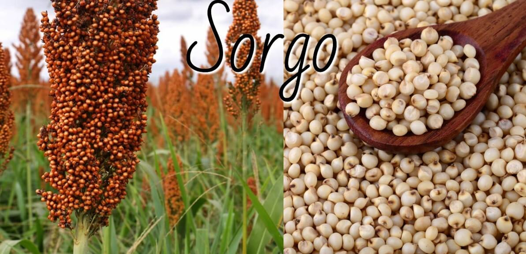

Vvivir sin gluten. (2019)Sorgo. Recuperado en:https://vivirsingluten.online/sorgo/ Consultado (07/03/2021)

## Bibliografía

1. SAGARPA (2017) Sorgo Grano mexicano. Recuperado en: https://www.gob.mx/cms/uploads/attachment/file/256433/B_sico-Sorgo_Grano.pdf Consultado (07/03/2021) Hora 10:28 p.m.